# RESEARCH PROTOCOL DOSETTE: DOsing Schedule Evaluation using Target Trial Emulation, for Childhood Pneumococcal Conjugate Vaccines

Version: 0.1.0

# 1 List of Abbreviations

| CDM | Common data model |
| --- | --- |
| ICD-10 | International Classification of Diseases, Tenth Revision |
| ICH | International Council for Harmonisation of Technical Requirements for Pharmaceuticals for Human Use |
| IPD | Invasive pneumococcal diseases |
| NIP | National Immunization Program |
| OHDSI | Observational Health Data Sciences and Informatics |
| PCV | Pneumococcal conjugate vaccine |
| PCV7 | 7-valent pneumococcal conjugate vaccine |
| PCV10 | 10-valent pneumococcal conjugate vaccine |
| PCV13 | 13-valent pneumococcal conjugate vaccine |
| PPSV23 | 23-valent pneumococcal polysaccharide vaccine |
| RCT | Randomized controlled trial |
| SAGE | Strategic Advisory Group of Experts on Immunization |
| TTE | Target trial emulation |
| WHO | World Health Organization |

# 2 Responsible Parties

## 2.1 Investigators

| Investigator | Institution/Affiliation |
| --- | --- |
| Fan Bu* | University of Michigan, Ann Arbor, MI, USA |
| Kayoko Shioda * | Boston University School of Public Health, Boston, MA, USA |

* Principal Investigator

## 2.2 Disclosures

This study is undertaken within Observational Health Data Sciences and Informatics (OHDSI), an open collaboration. **FB** and **KS** received funding from the Bill and Melinda Gates Foundation (BMGF).

# 3 Abstract

**Background and Significance**: Pneumococcal conjugate vaccines (PCVs) prevent morbidity and mortality among children and adults, but they are among the most expensive vaccines, competing for limited public health resources.[1] To address this challenge, the World Health Organization (WHO) Strategic Advisory Group of Experts on Immunization (SAGE) has been gathering data to evaluate the potential impact of switching from the existing 2+1 or 3+0 PCV dosing schedules to the 1+1 schedule and plans to provide a recommendation in early 2025. Randomized controlled trials (RCTs) are the gold standard for comparing dosing schedules but are often resource-intensive and may only include small, selected subpopulations from certain regions (e.g., high-income countries, urban settings) over short periods. Instead, we propose to use a novel causal inference method using observational data, called target trial emulation (TTE). [4] We will implement observational studies that explicitly emulate a hypothetical RCT using large-scale observational healthcare data.

**Study Aims**: Our study aims to evaluate the comparative effectiveness of different PCV13 dosing schedules among children under five years of age, using OHDSI network data sources.

**Study Description**:

- **Population**: Our target population consists of vaccine-eligible children born between 2010 and 2023, who received at least one dose of PCV13 by the time they turn 15 months of age. Within the US, where the data source does have state-level location information, the main study will cover 37 states that do not have universal childhood vaccination programs (thus we will exclude children residing in Alaska, Idaho, Massachusetts, Maine, North Dakota, New Hampshire, New Mexico, Oregon, Rhode Island, Vermont, Washington, Wisconsin, Wyoming); a sensitivity analysis will include all 50 states in the US.
- **Comparators**: Our study will evaluate the impact of different dosing schedules of PCV, specifically the PCV13. We will compare the recommended dosing schedule (3+1 doses: three doses administered in the first year of life followed by a booster shot in the second year) with reduced dosing schedules (e.g., 3+0, 2+1, 2+0, 1+1, 1+0, and 0+1 doses). Additionally, we will analyze the comparative effects of alternate timings for each dose (e.g., comparing two 2-dose schedules: one administered at 2 and 12 months of age versus another administered at 6 and 12 months of age) if there are enough variations in the actual timing of doses followed by children.
- **Outcomes**: The primary outcome measure is the estimated cumulative risk of the selected clinical outcome among children under five years of age in the U.S., assuming that all vaccine-eligible children followed each of the specific PCV dosing schedules (e.g., 3+1, 2+1, 1+1). The secondary outcome measures include trends in adherence to the recommended PCV dosing schedule (3+1 schedule) in the U.S. from 2010 to 2023 among sub-populations (e.g., different age groups and geographic areas).
- **Design**: We will apply one of the TTE approaches, clone-censor weight analysis, [8] to compare the effectiveness of different numbers of PCV doses and the timing of each dose among children under five years of age.

# 4 Amendments and Updates

| Number | Date | Section of study protocol | Amendment or update | Reason |
| --- | --- | --- | --- | --- |

# 5 Milestones

| Milestone | Planned / actual date |
| --- | --- |
| 1st draft of study protocol | 09/20/2024 |
| Updated study protocol | 17/02/2025 |

# 6 Rationale and Background

Pneumococcal conjugate vaccines (PCVs) prevent morbidity and mortality among children and adults, but they are among the most expensive vaccines, competing for limited public health resources.[1] To address this challenge, the World Health Organization (WHO) Strategic Advisory Group of Experts on Immunization (SAGE) has been gathering data to evaluate the potential impact of switching from the existing 2+1 or 3+0 PCV dosing schedules to the 1+1 schedule and plans to provide a recommendation in early 2025. Randomized controlled trials (RCTs) are the gold standard for comparing dosing schedules but are often resource-intensive and may only include small, selected subpopulations from certain regions (e.g., high-income countries, urban settings) over short periods. Instead, we propose to use a novel causal inference method using observational data, called target trial emulation (TTE).[4] We will design observational studies that explicitly emulate a hypothetical RCT using large nationwide data in the U.S. Using TTE, we will estimate the impact of switching from the currently recommended schedule (3+1 schedule: three doses administered in the first year of life followed by a booster shot in the second year) to reduced doses (e.g., 2+1, 1+1, 1+0) on various clinical outcomes, such as pneumonia and meningitis, among the general pediatric population (aged ≤ 59 months) across the country. In the U.S., the 7-valent PCV (PCV7) was introduced in the childhood routine immunization program in 2000, and the product was switched to PCV13 in 2010. This TTE approach is an affordable alternative to RCTs with various practical and methodological advantages.[4] TTE can be readily applied to countries with existing data but lacking resources for a full RCT to guide vaccine policies based on local evidence.

Pneumococcal conjugate vaccines (PCVs) are among the most expensive vaccines.[1] As many countries transition from financial support from international donors like Vaccine Alliance (GAVI), it is crucial for decision-makers to review current vaccine policies based on scientific evidence and allocate limited public health resources appropriately. Generating scientific evidence based on local data is vital, as countries vary in disease burden, pneumococcus serotype distributions, population characteristics, and transmission levels, all of which may alter the optimal dosing schedule. [9] Therefore, we propose to conduct a TTE study, which will allow us to emulate a hypothetical RCT using existing surveillance data.[2] This approach is a cost-effective alternative to RCTs for generating evidence based on local data to guide vaccine policies.

TTE studies are advantageous because they can evaluate PCV dosing schedules among the general population, whereas RCTs often focus on small, limited study populations. This is an timely moment to conduct this study, as the WHO SAGE is scheduled to discuss this specific issue in early 2025. We will make the analytic protocols and tools developed in this study publicly available (e.g., R packages, results R ShinyApps), which can be readily applied to evaluating dosing schedules for other vaccines.

# 7 Study Objectives

Our **primary objective** is to compare the effectiveness of different PCV dosing schedules in preventing various clinical outcomes, such as pneumonia and meningitis, among children under five years old. Our **secondary objective** is to describe the trend in adherence to the recommended PCV schedules across various sub-populations (e.g., race/ethnicity, geographic areas) over time.

# 8 Research Methods

Using existing observational healthcare databases across the OHDSI network, we will apply one of the TTE approaches, clone-censor weight analysis,[8] to compare the effectiveness of different numbers of PCV doses and the timing of each dose among children under five years of age in the U.S. Clone-censor weight analysis offers practical and analytical advantages.[6]  
This method allows us to emulate a hypothetical RCT, where participants are assigned to different PCV dosing schedules, such as 3+1 and 1+1 schedules. This method’s major advantage is the ability to compare dosing schedules for the entire course of vaccination, including interdose intervals (e.g., between the first and second doses or between the primary series and the booster dose).[7]

The clone-censor weight analysis will emulate a hypothetical trial by recruiting all individuals in the target population and assigning them to each compared dosing schedule, a process referred to as ``cloning”.[6] Follow-up starts on day 38 after birth, which is the date when a child becomes eligible to receive their first PCV dose, and ends at the earliest occurrence of the following: the clinical outcome, the end of the study period, the child’s fifth birthday, or non-adherence to the assigned dosing schedule.

## 8.1 Study Design

This will be a retrospective observational study, emulating a hypothetical RCT through clone-censor weight analysis (a target trial emulation method).

## 8.2 Data Sources

We will execute this study as an OHDSI network study. All data partners within OHDSI are encouraged to participate voluntarily and can do so conveniently, because of the community’s shared Observational Medical Outcomes Partnership (OMOP) common data model (CDM) and OHDSI tool-stack. We are actively recruiting OHDSI community data partner through OHDSI’s standard recruitment process, which includes protocol publication on OHDSI’s GitHub, an announcement in OHDSI’s research forum, presentation at the weekly OHDSI all-hands-on meeting and direct requests to data holders.

## 8.3 Study Population

Vaccine-eligible children born between 2010 (when the PCV13 was introduced into the routine childhood immunization program in the U.S.) and 2023, who did not experience any severe allergic reactions to vaccination by day 37 after birth (one day before the recommended earliest day for the first dose PCV13). While comparing effectiveness of different dosing schedules, we further restrict to those children who received at least one dose of PCV13 by the time they turn 15 months of age (i.e., 456 days after birth). In the US., wherever state-level location information is available, the main study will only cover 37 states (states other than Alaska, Idaho, Massachusetts, Maine, North Dakota, New Hampshire, New Mexico, Oregon, Rhode Island, Vermont, Washington, Wisconsin, and Wyoming) since the thirteen states with universal childhood vaccination programs will have incomplete insurance claims records;our sensitivity analysis will include all 50 states in the US.

## 8.4 Exposure Comparators

We will compare the effectiveness of the recommended PCV 3+1 schedule (three doses in the first year of life and a booster in the second year) and reduced dosing schedules (e.g., 2+1, 2+0, 1+1, 1+0).

Specifically, we consider these dosing schedules as recommended:

- 1st dose: 2 months of age, which is 38 – 92 days of age
- 2nd dose: 4 months of age, which is 113 – 141 days of age (= from 120-7 days to 120+21 days)
- 3rd dose: 6 months of age, which is 173 – 201 days of age (= from 180-7 days to 180+21 days)
- 4th dose: 12 – 15 months of age, which is 358 – 476 days of age (= from 365-7 days to 365+90+21 days

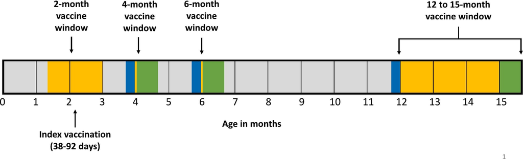

Figure 8.1: Standard PCV dosing schedule. From Butler et. al. 2024.

Missing doses would be considered as following a reduced dosing schedule, and deviation from the recommended administration time windows will be considered as off schedule.

As a secondary analysis, we may also compare various timings of each dose, based on actual variations observed in the data.

## 8.5 Outcomes

We will evaluate the comparative effectiveness of different PCV dosing schedules against the following clinical outcomes among children under five years of age in the U.S.:

- Hospitalization and/or death due to all-cause pneumonia (ICD-10 code: J12-J18)
- Hospitalization and/or death due to pneumococcal meningitis (ICD-10 code: G00.1)
- Hospitalization and/or death due to all-cause meningitis (ICD-10 code: G00, G02, G03)
- Hospitalization due to invasive pneumococcal diseases (IPD) (ICD-10 code: A40, G00.1, J13)

Pneumococcal pneumonia is not included because the ICD-10 code [J13] is rarely used due to limited testing. Instead, we will use all-cause pneumonia, which was used as an outcome in previous studies for this reason. [14]

## 8.6 Analysis

We will use a TTE approach, clone-censor weight analysis,[7] to understand how the different numbers of PCV doses and the timing of each dose may change the risk of the aforementioned clinical outcomes among children under five years of age. This method mimics a per-protocol analysis of a RCT in which individuals are randomly allocated to alternative dosing schedules.

**Cloning process in the clone-censor weight analysis**: For the comparison of the 3+1 schedule (recommended schedule) and the reduced dosing schedule, we will create copies of the longitudinal dataset corresponding to each dosing schedule of interest. This process is referred to as “cloning” in the TTE framework.[7] In each copy, individuals will be followed up from the Day 38, which is the index date when each individual becomes eligible to receive the vaccine, until the earliest occurrence of the following: the clinical outcome, the end of the study period, the child’s fifth birthday, or non-adherence to the assigned dosing schedule. This method addresses measured confounding at baseline because the copies of each observation are identical at the start of follow-up. In each schedule-specific copy, a vaccine recipient who does not follow a given dosing schedule will be considered non-adherent and will be censored at the time their dosing schedule differs from the specified schedule. See Figure 8.2 for an illustration using a 4-person toy example to produce the ``clones” for the FDA-recommended dosing schedule.

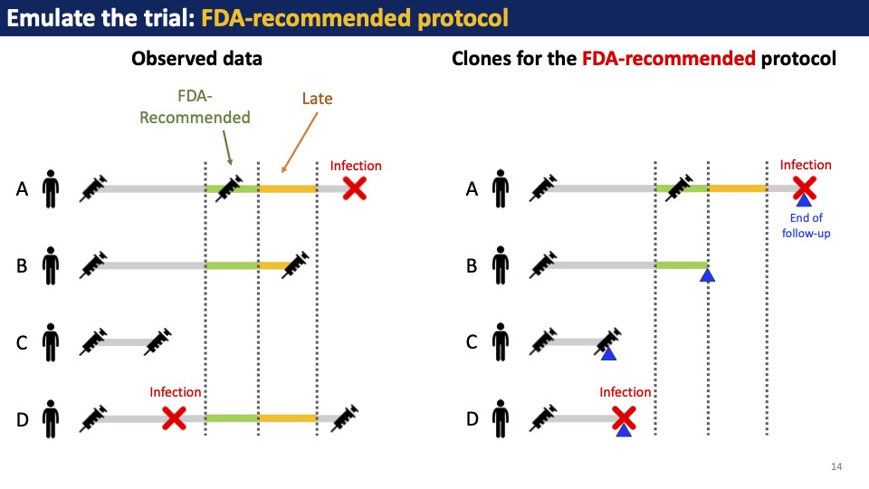

Figure 8.2: Diagram of the cloning process for the FDA-recommended dosing schedule, using a four-person toy example.

**Inverse probability of censoring weights in the clone-censor weight analysis**: Informative censoring due to dosing schedule non-adherence will be addressed with inverse probability of censoring weights.[7] We will fit a Cox proportional hazards and a pooled logistic regression model to the longitudinal dataset under each dosing schedule, where the outcome of being censored is adjusted for covariates including birth month, birth year, infant overnight hospitalizations, geographic region and state (when available), mother’s maternal age at birth (when available) and number of siblings (when available). Subsequently, this model will be used to estimate the probability of remaining uncensored at each person’s event time. The reciprocal of this probability will serve as the censoring weights. These weights are designed to up-weight individuals who remain adherent to the dosing schedule at each time to have the same covariate distribution as the entire study population. This process will allow us to create a weighted population that represents the entire study population had all individuals remained adherent to the certain dosing schedule throughout follow-up.

**Evaluation of comparative effectiveness in the clone-censor weight analysis**: For each of the schedule-specific copies, we will calculate the weighted cumulative risk of each clinical outcome had the total study population followed the corresponding dosing schedule. To compare the effectiveness of different dosing schedules, we will calculate ratios of the weighted cumulative risks, setting the recommended protocol (3+1) as a reference. We will compute 95% confidence intervals using a nonparametric bootstrap. We will evaluate if the comparative effectiveness differs across age groups (<12, 12-23, 24-59 months), race/ethnicity groups, geographic areas, and over time (from 2010-2023).

## 8.7 Study Hypotheses

We hypothesize that the reduced PCV doses can maintain low incidences of clinical outcomes of interest among children under 5 years of age. Comparative effectiveness of the recommended and reduced dosing schedules may differ by detailed age groups (<12, 12-23, 24-59 months), geographic areas, and over time.

# 9 Sample Size and Study Power

This study utilizes data sources from OHDSI data partners, and as such, there is no prospective sample collection or traditional sample size calculation. The analysis will include all available data for all eligible children within the specified time frame (2010-2023) that meet the inclusion criteria. Thus, the sample size is effectively determined by the availability of data rather than a predefined number. This approach ensures that our analysis is as inclusive and comprehensive as possible, enhancing the validity and generalizability of the study findings.

# 10 Strengths and Limitations

## 10.1 Strengths

- By using the target trial emulation (TTE) method, we can emulate a hypothetical target trial with nationwide data spanning over 10 years (2010-2023), unlike RCTs which tend to focus on smaller populations over shorter time periods.
- Our broad population coverage enables the evaluation of vaccine dosing schedules across the general population, unlike RCTs which tend to involve more limited populations.
- Our extensive data size allows us to examine the effectiveness of different dosing schedules on rare outcomes, such as hospitalization due to invasive pneumococcal diseases and meningitis. Due to its small study population, RCTs generally need to focus on more common outcomes (e.g., an increase in antibody titer).
- Our broad population coverage facilitates analysis of differences in comparative effectiveness across subpopulations (e.g., specific age groups, racial groups, and geographic regions) as well as temporal changes. Temporal changes are particularly important for observing the potential impacts of pneumococcal serotype replacement, which may mask the effects of PCVs.
- The use of observational data allows us to bypass the ethical and logistical challenges associated with randomizing infants into different dosing schedules.

## 10.2 Limitations

- The feasibility of TTE depends on real-world variations in dosing schedules. From 2010 to 2016, CDC data shows an average of 81.4% coverage for 4+ PCV doses by age 24 months in the U.S., with significant demographic and geographic differences, which may provide sufficient variation for the proposed TTE analysis.
- Most clinical outcomes in our data are not vaccine-type-specific due to the absence of serotype information. Due to this limitation, we will use broader, non-specific outcomes, which may potentially reduce the sensitivity of our evaluation.
- Low incidence of invasive pneumococcal disease among U.S. children under five may limit the power to detect significant differences in PCV effectiveness across dosing schedules, though the OHDSI network’s large, long-term dataset may help improve study power.
- OHDSI data may miss death events, as these are often not submitted to insurance claims.
- Important factors such as gestational age, household characteristics (e.g., number of children), and maternal characteristics (e.g., education, health) that may impact both exposures and outcomes are not captured in OHDSI data.
- OHDSI lacks detailed geographic data for each patient, making it difficult to capture regional variations in outcomes.
- It can be challenging to determine if a patient is lost to follow-up due to an insurance change or simply because they did not seek care.
- TTE currently can only evaluate the direct effects of vaccine dosing schedules.
- This study focuses on children under five years of age, though future analyses could explore older age groups.

# 11 Protection of Human Subjects

This study is to be conducted in accordance with applicable US federal regulations and institutional policies, which are based on federal regulations, guidance, and International Council for Harmonisation of Technical Requirements for Pharmaceuticals for Human Use (ICH) Good Clinical Practice guidelines.

To protect the privacy of participants, any shared data will be de-identified where possible. The inclusion of the date of birth will be handled with additional safeguards to ensure confidentiality. Data sharing agreements will stipulate the conditions under which PII can be accessed and used, ensuring compliance with privacy standards and regulations.

All study-related documentation and data will be handled in accordance with institutional and federal regulations to ensure accuracy, integrity, and confidentiality of data. Study records will be retained for at least seven years after the completion of the study, or as otherwise required by institutional or federal guidelines.

# 12 Management and Reporting of Adverse Events and Adverse Reactions

This study uses coded data that already exist in electronic databases. In these types of databases, it is not usually possible to link (i.e., identify a potential causal association between) a particular product and medical event for any specific individual. Thus, the minimum criteria for reporting an adverse event (i.e., identifiable patient, identifiable reporter, a suspect product and event) are not available and adverse events are not reportable as individual adverse event reports. The study results will be assessed for medically important findings.

# 13 Plans for Disseminating and Communicating Study Results

We plan to summarize findings in manuscripts and meeting presentations. We will make all study results publicly available using interactive RShinyApps, share study findings at OHDSI all-hands meetings and at the OHDSI global symposiums.

# References

1

VFC current CDC vaccine price list CDC. 2023.https://www.cdc.gov/vaccines/programs/vfc/awardees/vaccine-management/price-list/index.html (accessed 8 Sep 2023).

2

Hernán MA, Robins JM. Using big data to emulate a target trial when a randomized trial is not available. *American Journal of Epidemiology* 2016;**183**:758–64. doi:10.1093/aje/kwv254

3

Hernán MA, Wang W, Leaf DE. Target trial emulation: A framework for causal inference from observational data. *JAMA* 2022;**328**:2446–7. doi:10.1001/jama.2022.21383

4

Hernán MA, Sauer BC, Hernández-Díaz S, *et al.* Specifying a target trial prevents immortal time bias and other self-inflicted injuries in observational analyses. *Journal of Clinical Epidemiology* 2016;**79**:70–5. doi:10.1016/j.jclinepi.2016.04.014

5

Maringe C, Benitez Majano S, Exarchakou A, *et al.* Reflection on modern methods: Trial emulation in the presence of immortal-time bias. Assessing the benefit of major surgery for elderly lung cancer patients using observational data. *International Journal of Epidemiology* 2020;**49**:1719–29. doi:10.1093/ije/dyaa057

6

Zhao SS, Lyu H, Yoshida K. Versatility of the clone-censor-weight approach: Response to ‘trial emulation in the presence of immortal-time bias’. *International Journal of Epidemiology* 2021;**50**:694–5. doi:10.1093/ije/dyaa223

7

Shioda K, Breskin A, Harati P, *et al.* Comparative effectiveness of alternative intervals between first and second doses of the mRNA COVID-19 vaccines. *Nat Commun* 2024;**15**:1214. doi:10.1038/s41467-024-45334-8

8

Butler AM, Breskin A, Sahrmann JM, *et al.* Estimating the effectiveness of rotavirus vaccine schedules. *Epidemiology* 2021;**32**:598–606. doi:10.1097/EDE.0000000000001363

9

Oliveira LH de, Shioda K, Valenzuela MT, *et al.* Declines in pneumonia mortality following the introduction of pneumococcal conjugate vaccines in latin american and caribbean countries. *Clinical Infectious Diseases* 2021;**73**:306–13.

10

Butler AM, Newland JG, Sahrmann JM, *et al.* Characterizing timeliness of recommended vaccinations among privately-insured children in the united states, 2009–2019. *Vaccine* 2024;**42**:126179.

11

Shioda K, Toscano CM, Valenzuela MT, *et al.* Impact of pneumococcal conjugate vaccine uptake on childhood pneumonia mortality across income levels in brazil, colombia, and peru. *Gates Open Research* 2020;**4**.

12

Shioda K, Schuck-Paim C, Taylor RJ, *et al.* Challenges in estimating the impact of vaccination with sparse data. *Epidemiology* 2019;**30**:61–8.

13

Warren JL, Shioda K, Kürüm E, *et al.* Impact of pneumococcal conjugate vaccines on pneumonia hospitalizations in high-and low-income subpopulations in brazil. *Clinical Infectious Diseases* 2017;**65**:1813–8.

14

Prunas O, Shioda K, Toscano CM, *et al.* Estimated population-level impact of pneumococcal conjugate vaccines against all-cause pneumonia mortality among unvaccinated in 5 latin american countries. *The Journal of Infectious Diseases* 2024;jiae144.

# A Exposure Cohort Definitions

## A.1 All PCV 13 Vaccinees By 15 Months

### A.1.1 Cohort Entry Events

People with continuous observation of 30 days before and 1 days after event may enter the cohort when observing any of the following:

1. drug exposures of ‘PCV13’, starting on or after January 1, 2010.

### A.1.2 Additional Inclusion Criteria

#### I. Age <= 2 to exclude older vaccinees: Exclude older patients by restricting on babies

Entry events with any of the following criteria:

1. having at least 1 condition occurrence of ‘Newborn event’, starting between 456 days before and 0 days after cohort entry start date; starting between January 1, 2010 and December 31, 2023; with all of the following criteria:
   1. having no condition occurrences of ‘Anaphylactic reaction to vaccination’, starting between 0 days before and 37 days after ‘Newborn event’ start date.
   2. having no condition occurrences of ‘Severe combined immunodeficiency’, starting between 0 days before and 37 days after ‘Newborn event’ start date.
2. having at least 1 observation of ‘liveborn event (observation)’, starting between 456 days before and 0 days after cohort entry start date; starting between January 1, 2010 and December 31, 2023; with all of the following criteria:
   1. having no condition occurrences of ‘Anaphylactic reaction to vaccination’, starting between 0 days before and 37 days after ‘liveborn event (observation)’ start date.
   2. having no condition occurrences of ‘Severe combined immunodeficiency’, starting between 0 days before and 37 days after ‘liveborn event (observation)’ start date.

### A.1.3 Cohort Exit

The cohort end date will be offset from index event’s start date plus 1 day.

### A.1.4 Cohort Eras

Remaining events will be combined into cohort eras if they are within 3 days of each other.

### A.1.5 Concept: Anaphylactic reaction to vaccination

| Concept ID | Concept Name | Code | Vocabulary | Excluded | Descendants | Mapped |
| --- | --- | --- | --- | --- | --- | --- |
| 442038 | Anaphylactic shock due to serum | 213320003 | SNOMED | NO | YES | NO |

### A.1.6 Concept: Newborn event

| Concept ID | Concept Name | Code | Vocabulary | Excluded | Descendants | Mapped |
| --- | --- | --- | --- | --- | --- | --- |
| 4092289 | Livebirth | 281050002 | SNOMED | NO | YES | NO |

### A.1.7 Concept: Severe combined immunodeficiency

| Concept ID | Concept Name | Code | Vocabulary | Excluded | Descendants | Mapped |
| --- | --- | --- | --- | --- | --- | --- |
| 29783 | Severe combined immunodeficiency disease | 31323000 | SNOMED | NO | YES | NO |

### A.1.8 Concept: PCV13

| Concept ID | Concept Name | Code | Vocabulary | Excluded | Descendants | Mapped |
| --- | --- | --- | --- | --- | --- | --- |
| 40213198 | pneumococcal conjugate vaccine, 13 valent | 133 | CVX | NO | YES | NO |

### A.1.9 Concept: liveborn event (observation)

| Concept ID | Concept Name | Code | Vocabulary | Excluded | Descendants | Mapped |
| --- | --- | --- | --- | --- | --- | --- |
| 40482735 | Liveborn born in hospital | 442311008 | SNOMED | NO | YES | YES |

## A.2 All Liveborn Babies Eligible for Vaccination

### A.2.1 Cohort Entry Events

People with continuous observation of 37 days after event may enter the cohort when observing any of the following:

1. condition occurrences of ‘Newborn event’, starting on or after January 1, 2010; with all of the following criteria:
2. having no condition occurrences of ‘Anaphylactic reaction to vaccination’, starting between 0 days before and 37 days after ‘Newborn event’ start date.
3. having no condition occurrences of ‘Severe combined immunodeficiency’, starting between 0 days before and 37 days after ‘Newborn event’ start date.

Limit cohort entry events to the earliest event per person.

### A.2.2 Additional Inclusion Criteria

#### I. Age < 1: Make sure it’s newborn, rather than mother giving birth

The person also exists the cohort at the end of continuous observation.

The person also exists the cohort when encountering any of the following events:

Remaining events will be combined into cohort eras if they are within 1 days of each other.

### A.2.3 Concept: Newborn event

| Concept ID | Concept Name | Code | Vocabulary | Excluded | Descendants | Mapped |
| --- | --- | --- | --- | --- | --- | --- |
| 4092289 | Livebirth | 281050002 | SNOMED | NO | YES | NO |
| 40482735 | Liveborn born in hospital | 442311008 | SNOMED | NO | YES | NO |

### A.2.4 Concept: Anaphylactic reaction to vaccination

| Concept ID | Concept Name | Code | Vocabulary | Excluded | Descendants | Mapped |
| --- | --- | --- | --- | --- | --- | --- |
| 442038 | Anaphylactic shock due to serum | 213320003 | SNOMED | NO | YES | NO |

### A.2.5 Concept: Severe combined immunodeficiency

| Concept ID | Concept Name | Code | Vocabulary | Excluded | Descendants | Mapped |
| --- | --- | --- | --- | --- | --- | --- |
| 29783 | Severe combined immunodeficiency disease | 31323000 | SNOMED | NO | YES | NO |

# B Outcome Cohort Definitions

## B.1 Hospitalization due to all-cause pneumonia

### B.1.1 Cohort Entry Events

People may enter the cohort when observing any of the following:

1. condition occurrences of ‘All-cause pneumonia’.

### B.1.2 Additional Inclusion Criteria

#### I. Has Inpatient or ER visit

Entry events having at least 1 visit occurrence of ‘Inpatient or ER visit’, starting anytime on or before cohort entry start date and ending between 0 days before and all days after cohort entry start date.

#### II. Age between 38 days and 5 years: Use newborn event occurrence >= 38 days ago to define age >= 38 days when outcome occurred

Entry events with all of the following criteria:

1. with the following event criteria: who are <= 5 years old.
2. having at least 1 condition occurrence of ‘Newborn event’, starting anytime up to 38 days before cohort entry start date.

Limit qualifying entry events to the all events per person.

### B.1.3 Cohort Exit

The cohort end date will be offset from index event’s end date plus 1 day.

### B.1.4 Cohort Eras

Remaining events will be combined into cohort eras if they are within 0 days of each other.

### B.1.5 Concept: Inpatient or ER visit

| Concept ID | Concept Name | Code | Vocabulary | Excluded | Descendants | Mapped |
| --- | --- | --- | --- | --- | --- | --- |
| 262 | Emergency Room and Inpatient Visit | ERIP | Visit | NO | YES | NO |
| 9203 | Emergency Room Visit | ER | Visit | NO | YES | NO |
| 9201 | Inpatient Visit | IP | Visit | NO | YES | NO |

### B.1.6 Concept: All-cause pneumonia

| Concept ID | Concept Name | Code | Vocabulary | Excluded | Descendants | Mapped |
| --- | --- | --- | --- | --- | --- | --- |
| 255848 | Pneumonia | 233604007 | SNOMED | NO | YES | NO |
| 261326 | Viral pneumonia | 75570004 | SNOMED | YES | YES | NO |
| 258785 | Pneumococcal pneumonia | 233607000 | SNOMED | NO | YES | NO |
| 260754 | Haemophilus influenzae pneumonia | 70036007 | SNOMED | NO | YES | NO |
| 260754 | Haemophilus influenzae pneumonia | 70036007 | SNOMED | NO | YES | NO |
| 257315 | Bacterial pneumonia | 53084003 | SNOMED | NO | YES | NO |
| 443410 | Infective pneumonia | 312342009 | SNOMED | NO | YES | NO |

### B.1.7 Concept: Newborn event

| Concept ID | Concept Name | Code | Vocabulary | Excluded | Descendants | Mapped |
| --- | --- | --- | --- | --- | --- | --- |
| 4092289 | Livebirth | 281050002 | SNOMED | NO | YES | NO |

## B.2 Hospitalization due to all-cause meningitis

### B.2.1 Cohort Entry Events

People may enter the cohort when observing any of the following:

1. condition occurrences of ‘All-cause meningitis’.

### B.2.2 Additional Inclusion Criteria

#### I. Has Inpatient or ER visit

Entry events having at least 1 visit occurrence of ‘Inpatient or ER visit’, starting anytime on or before cohort entry start date and ending between 0 days before and all days after cohort entry start date.

#### II. Age between 38 days and 5 years: Use newborn event occurrence >= 38 days ago to define age >= 38 days when outcome occurred

Entry events with all of the following criteria:

1. with the following event criteria: who are <= 5 years old.
2. having at least 1 condition occurrence of ‘Newborn event’, starting anytime up to 38 days before cohort entry start date.

Limit qualifying entry events to the all events per person.

### B.2.3 Cohort Exit

The cohort end date will be offset from index event’s end date plus 1 day.

### B.2.4 Cohort Eras

Remaining events will be combined into cohort eras if they are within 0 days of each other.

### B.2.5 Concept: Inpatient or ER visit

| Concept ID | Concept Name | Code | Vocabulary | Excluded | Descendants | Mapped |
| --- | --- | --- | --- | --- | --- | --- |
| 262 | Emergency Room and Inpatient Visit | ERIP | Visit | NO | YES | NO |
| 9203 | Emergency Room Visit | ER | Visit | NO | YES | NO |
| 9201 | Inpatient Visit | IP | Visit | NO | YES | NO |

### B.2.6 Concept: All-cause meningitis

| Concept ID | Concept Name | Code | Vocabulary | Excluded | Descendants | Mapped |
| --- | --- | --- | --- | --- | --- | --- |
| 436091 | Bacterial meningitis | 95883001 | SNOMED | NO | YES | NO |
| 4207307 | Infective meningitis | 312216007 | SNOMED | NO | YES | NO |
| 435785 | Meningitis | 7180009 | SNOMED | NO | YES | NO |

### B.2.7 Concept: Newborn event

| Concept ID | Concept Name | Code | Vocabulary | Excluded | Descendants | Mapped |
| --- | --- | --- | --- | --- | --- | --- |
| 4092289 | Livebirth | 281050002 | SNOMED | NO | YES | NO |

## B.3 Hospitalization due to pneumococcal meningitis

### B.3.1 Cohort Entry Events

People may enter the cohort when observing any of the following:

1. condition occurrences of ‘Pneumococcal meningitis’.

### B.3.2 Additional Inclusion Criteria

#### I. Has Inpatient or ER visit

Entry events having at least 1 visit occurrence of ‘Inpatient or ER visit’, starting anytime on or before cohort entry start date and ending between 0 days before and all days after cohort entry start date.

#### II. Age between 38 days and 5 years: Use newborn event occurrence >= 38 days ago to define age >= 38 days at outcome occurrence

Entry events with all of the following criteria:

1. with the following event criteria: who are <= 5 years old.
2. having at least 1 condition occurrence of ‘Newborn event’, starting anytime up to 38 days before cohort entry start date.

Limit qualifying entry events to the all events per person.

### B.3.3 Cohort Exit

The cohort end date will be offset from index event’s end date plus 1 day.

### B.3.4 Cohort Eras

Remaining events will be combined into cohort eras if they are within 0 days of each other.

### B.3.5 Concept: Inpatient or ER visit

| Concept ID | Concept Name | Code | Vocabulary | Excluded | Descendants | Mapped |
| --- | --- | --- | --- | --- | --- | --- |
| 262 | Emergency Room and Inpatient Visit | ERIP | Visit | NO | YES | NO |
| 9203 | Emergency Room Visit | ER | Visit | NO | YES | NO |
| 9201 | Inpatient Visit | IP | Visit | NO | YES | NO |

### B.3.6 Concept: Pneumococcal meningitis

| Concept ID | Concept Name | Code | Vocabulary | Excluded | Descendants | Mapped |
| --- | --- | --- | --- | --- | --- | --- |
| 432879 | Pneumococcal meningitis | 51169003 | SNOMED | NO | YES | NO |

### B.3.7 Concept: Newborn event

| Concept ID | Concept Name | Code | Vocabulary | Excluded | Descendants | Mapped |
| --- | --- | --- | --- | --- | --- | --- |
| 4092289 | Livebirth | 281050002 | SNOMED | NO | YES | NO |

## B.4 Hospitalization due to invasive pneumococcal diseases (IPD)

### B.4.1 Cohort Entry Events

People may enter the cohort when observing any of the following:

1. condition occurrences of ‘Invasive pneumococcal diseases’.

### B.4.2 Additional Inclusion Criteria

#### I. Has Inpatient or ER visit

Entry events having at least 1 visit occurrence of ‘Inpatient or ER visit’, starting anytime on or before cohort entry start date and ending between 0 days before and all days after cohort entry start date.

#### II. Age between 38 days and 5 years: Use newborn event occurrence >= 38 days ago to define age >= 38 days when outcome occurred

Entry events with all of the following criteria:

1. with the following event criteria: who are <= 5 years old.
2. having at least 1 condition occurrence of ‘Newborn event’, starting anytime up to 38 days before cohort entry start date.

Limit qualifying entry events to the all events per person.

### B.4.3 Cohort Exit

The cohort end date will be offset from index event’s end date plus 1 day.

### B.4.4 Cohort Eras

Remaining events will be combined into cohort eras if they are within 0 days of each other.

### B.4.5 Concept: Inpatient or ER visit

| Concept ID | Concept Name | Code | Vocabulary | Excluded | Descendants | Mapped |
| --- | --- | --- | --- | --- | --- | --- |
| 262 | Emergency Room and Inpatient Visit | ERIP | Visit | NO | YES | NO |
| 9203 | Emergency Room Visit | ER | Visit | NO | YES | NO |
| 9201 | Inpatient Visit | IP | Visit | NO | YES | NO |

### B.4.6 Concept: Invasive pneumococcal diseases

| Concept ID | Concept Name | Code | Vocabulary | Excluded | Descendants | Mapped |
| --- | --- | --- | --- | --- | --- | --- |
| 40489908 | Sepsis due to Streptococcus | 448418006 | SNOMED | NO | YES | NO |
| 432879 | Pneumococcal meningitis | 51169003 | SNOMED | NO | YES | NO |
| 258785 | Pneumococcal pneumonia | 233607000 | SNOMED | NO | YES | NO |

### B.4.7 Concept: Newborn event

| Concept ID | Concept Name | Code | Vocabulary | Excluded | Descendants | Mapped |
| --- | --- | --- | --- | --- | --- | --- |
| 4092289 | Livebirth | 281050002 | SNOMED | NO | YES | NO |

# C Negative Control Concepts

Table C.1: Negative control outcomes.

| Outcome Id | Outcome Name |
| --- | --- |
| 4152351 | Abdominal distension, gaseous |
| 381572 | Abducens nerve palsy |
| 443585 | Abrasion and/or friction burn of multiple sites |
| 436445 | Abrasion of tooth |
| 4058350 | Abrasion, knee |
| 4310082 | Accidental poisoning by cannabis derivatives |
| 436615 | Accidental poisoning from berries and seeds |
| 438719 | Active rickets |
| 433454 | Adjustment disorder with mixed emotional features |
| 4173136 | Agnosia |
| 76725 | Anal fissure |
| 434374 | Anisocoria |
| 312934 | Atherosclerosis of aorta |
| 313217 | Atrial fibrillation |
| 316135 | Atrioventricular block |
| 4045471 | Autoimmune reaction mediated by cell-mediated immunity |
| 45763685 | Avulsion fracture of medial epicondyle of humerus |
| 4162322 | Beta-adrenoceptor agonist poisoning |
| 134765 | Cachexia |
| 433758 | Childhood emotional disorder |
| 434344 | Ciliary muscle spasm |
| 81426 | Closed fracture of clavicle |
| 46269889 | Complication due to Crohn’s disease |
| 443617 | Conduct disorder |
| 319835 | Congestive heart failure |
| 75860 | Constipation |
| 138604 | Contusion of face, scalp and neck, excluding eye(s) |
| 4311591 | Cramp in limb |
| 80242 | Current tear of medial cartilage AND/OR meniscus of knee |
| 40481358 | Cutis laxa of upper eyelid |

[output cut: 127 more lines]